# TeamProject_week7_CB

CHAEBEOM

2022-08-08

### [ 자전거 대여 수요에 대한 예측 ]

#### ———————————————————————————————–

#### 1. 파일 로딩

#### 2. 변수 유형 및 특성

#### 3. 결측치 확인

#### 4. 데이터들의 속성 및 관계 파악

#### - 시간당 대여량을 ‘시간 관련 / 등록 여부 / 날씨 관련’

#### ———————————————————————————————–

#### 목적 : 자전거를 임대하는 수단인 ’자전거 공유 시스템’의 대여 정확한 수요 예측

#### ———————————————————————————————–

#### 1. 파일 로딩

```r
library('readxl')
bikeTr <- read.csv('./bike/train.csv', header = 1)
head(bikeTr)
```

```
##          datetime season holiday workingday weather temp  atemp humidity
## 1 2011-01-01 0:00      1       0          0       1 9.84 14.395       81
## 2 2011-01-01 1:00      1       0          0       1 9.02 13.635       80
## 3 2011-01-01 2:00      1       0          0       1 9.02 13.635       80
## 4 2011-01-01 3:00      1       0          0       1 9.84 14.395       75
## 5 2011-01-01 4:00      1       0          0       1 9.84 14.395       75
## 6 2011-01-01 5:00      1       0          0       2 9.84 12.880       75
##   windspeed casual registered count
## 1    0.0000      3         13    16
## 2    0.0000      8         32    40
## 3    0.0000      5         27    32
## 4    0.0000      3         10    13
## 5    0.0000      0          1     1
## 6    6.0032      0          1     1
```

```r
# 일부 출력물 확인
```

#### ———————————————————————————————–

#### 2. 변수 유형 및 특성

```r
# 데이터 프레임 확인
str(bikeTr)
```

```
## 'data.frame':    10886 obs. of  12 variables:
##  $ datetime  : chr  "2011-01-01 0:00" "2011-01-01 1:00" "2011-01-01 2:00" "2011-01-01 3:00" ...
##  $ season    : int  1 1 1 1 1 1 1 1 1 1 ...
##  $ holiday   : int  0 0 0 0 0 0 0 0 0 0 ...
##  $ workingday: int  0 0 0 0 0 0 0 0 0 0 ...
##  $ weather   : int  1 1 1 1 1 2 1 1 1 1 ...
##  $ temp      : num  9.84 9.02 9.02 9.84 9.84 ...
##  $ atemp     : num  14.4 13.6 13.6 14.4 14.4 ...
##  $ humidity  : int  81 80 80 75 75 75 80 86 75 76 ...
##  $ windspeed : num  0 0 0 0 0 ...
##  $ casual    : int  3 8 5 3 0 0 2 1 1 8 ...
##  $ registered: int  13 32 27 10 1 1 0 2 7 6 ...
##  $ count     : int  16 40 32 13 1 1 2 3 8 14 ...
```

```r
# 행, 열 확인
dim(bikeTr)
```

```
## [1] 10886    12
```

```r
# 컬럼명 확인
colnames(bikeTr)
```

```
##  [1] "datetime"   "season"     "holiday"    "workingday" "weather"
##  [6] "temp"       "atemp"      "humidity"   "windspeed"  "casual"
## [11] "registered" "count"
```

1) 관측값 vs. 변수

- 관측값 : 10886개
- 변수 : 12개  
  -> 변수가 많은 데이터셋은 그것대로 고민, 적어도 적은대로 고민  
  -> 해당 데이터셋의 컬럼간의 관계에 주목하는 것에 더 초점을 맞춰야겠다

2) 범주형 vs. 수치형

**범주형 변수** : 5개 (datetime, season, holiday, workingday, weather)

- datetime은 [ 연/월/일/시각 ]으로 떼어 생각한다고 생각하여 범주로 생각  
  -> 나머지는 각각 계절, 휴일/근무일 여부, 날씨 등으로 구분할 수 있다고 생각
- 시간형 자료의 활용에 주안점 => 년, 월, 일, 시간으로 끊어서

-> 년 -> 월 & 계절별 => 계절마다의 대여량  
-> 일 => train의 일수 vs. test의 일수 => 월초중 vs. 월말  
but, test에 count 데이터가 없으니 할 수 없음

-> 시간 => 하루 일과 시간을 기준으로 무엇인가 나올 것 같음 ex) 출퇴근 시간  
-> 추가적인 시간단위로 그래프 그려볼 것(반기, 분기 등)

- holiday, workingday => 0과 1의 차이 파악부터 해야 될 듯  
  -> 휴일날에 많이 쓰면, 특정 시간대에 많이 몰려있거나 -> 근무날에 많이 쓰면, 특정 시간대에 많이 몰려있거나  
  => 특정 이유가 있는 경우가 있을 것임

**수치형 변수** : 7개 (나머지)

- temp, atemp, humidity, windspeed  
  -> 온도와 상대온도를 굳이 나누어놨다는 것은 다르게 나타날 수도 있으니 확인  
  -> 나머지들은 단순 수치로 어떤 영향이 있는지 확인
- casual, registered, count  
  -> 미등록자와 등록자의 대여 대수 & 시간대 -> 입장에 따른 분석-유의미성이 다를 것임 => 상관관계 (시간대가 다르게 나옴)  
  -> [ count = casual + registered ]가 count가 종속변수

3) 종속변수 vs. 독립변수

- 종속변수 : 1개(count)
- 독립변수 : 나머지

#### ———————————————————————————————–

#### 3. 결측치 확인

```r
colSums(is.na(bikeTr))
```

```
##   datetime     season    holiday workingday    weather       temp      atemp
##          0          0          0          0          0          0          0
##   humidity  windspeed     casual registered      count
##          0          0          0          0          0
```

```r
# 결측치가 없구나. 처리할 고민은 하지 않아도 되겠군
# but, 결측치가 있는 데이터 간의 상관관계 등의 분석은 불필요
# 만약 존재했다면 -> 결측치끼리의 상관관계 유/무를 살펴봤을 것

library('VIM')
```

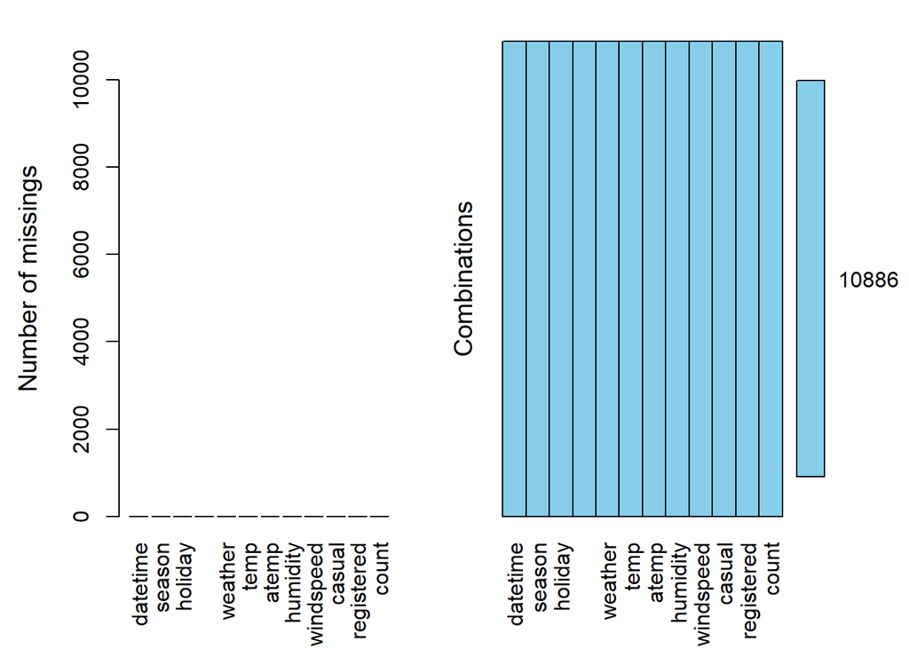

```r
aggr(bikeTr, prop=FALSE,numbers=TRUE)
```

```r
# 확인차. 없네요
```

#### ———————————————————————————————–

#### 4. 데이터 개별 속성의 값 및 관계 파악

#### 1) datetime

```r
library(lubridate)
# 기존 컬럼에 각 [ 연/월/일/시간 /반기별/분기별/요일별 ]에 해당하는 데이터 컬럼 추가
bikeTr$year <- year(bikeTr$datetime)
bikeTr$month <- month(bikeTr$datetime)
bikeTr$day <- day(bikeTr$datetime)
bikeTr$hour <- hour(bikeTr$datetime)

bikeTr$semester <- semester(bikeTr$datetime)
bikeTr$quarter <- quarter(bikeTr$datetime)
bikeTr$wday <- wday(bikeTr$datetime)

# 추가된 것 확인
colnames(bikeTr)
```

```
##  [1] "datetime"   "season"     "holiday"    "workingday" "weather"
##  [6] "temp"       "atemp"      "humidity"   "windspeed"  "casual"
## [11] "registered" "count"      "year"       "month"      "day"
## [16] "hour"       "semester"   "quarter"    "wday"
```

```r
str(bikeTr)
```

```
## 'data.frame':    10886 obs. of  19 variables:
##  $ datetime  : chr  "2011-01-01 0:00" "2011-01-01 1:00" "2011-01-01 2:00" "2011-01-01 3:00" ...
##  $ season    : int  1 1 1 1 1 1 1 1 1 1 ...
##  $ holiday   : int  0 0 0 0 0 0 0 0 0 0 ...
##  $ workingday: int  0 0 0 0 0 0 0 0 0 0 ...
##  $ weather   : int  1 1 1 1 1 2 1 1 1 1 ...
##  $ temp      : num  9.84 9.02 9.02 9.84 9.84 ...
##  $ atemp     : num  14.4 13.6 13.6 14.4 14.4 ...
##  $ humidity  : int  81 80 80 75 75 75 80 86 75 76 ...
##  $ windspeed : num  0 0 0 0 0 ...
##  $ casual    : int  3 8 5 3 0 0 2 1 1 8 ...
##  $ registered: int  13 32 27 10 1 1 0 2 7 6 ...
##  $ count     : int  16 40 32 13 1 1 2 3 8 14 ...
##  $ year      : num  2011 2011 2011 2011 2011 ...
##  $ month     : num  1 1 1 1 1 1 1 1 1 1 ...
##  $ day       : int  1 1 1 1 1 1 1 1 1 1 ...
##  $ hour      : int  0 1 2 3 4 5 6 7 8 9 ...
##  $ semester  : int  1 1 1 1 1 1 1 1 1 1 ...
##  $ quarter   : int  1 1 1 1 1 1 1 1 1 1 ...
##  $ wday      : num  7 7 7 7 7 7 7 7 7 7 ...
```

```r
head(bikeTr)
```

```
##          datetime season holiday workingday weather temp  atemp humidity
## 1 2011-01-01 0:00      1       0          0       1 9.84 14.395       81
## 2 2011-01-01 1:00      1       0          0       1 9.02 13.635       80
## 3 2011-01-01 2:00      1       0          0       1 9.02 13.635       80
## 4 2011-01-01 3:00      1       0          0       1 9.84 14.395       75
## 5 2011-01-01 4:00      1       0          0       1 9.84 14.395       75
## 6 2011-01-01 5:00      1       0          0       2 9.84 12.880       75
##   windspeed casual registered count year month day hour semester quarter wday
## 1    0.0000      3         13    16 2011     1   1    0        1       1    7
## 2    0.0000      8         32    40 2011     1   1    1        1       1    7
## 3    0.0000      5         27    32 2011     1   1    2        1       1    7
## 4    0.0000      3         10    13 2011     1   1    3        1       1    7
## 5    0.0000      0          1     1 2011     1   1    4        1       1    7
## 6    6.0032      0          1     1 2011     1   1    5        1       1    7
```

```r
# 각 시간적 요소의 평균값들의 count
m12_year <- aggregate(bikeTr, by=list(year=bikeTr$year),FUN=mean)$count
m12_semester <- aggregate(bikeTr, by=list(semester=semester(bikeTr$datetime)),FUN=mean)$count
m12_quarter <- aggregate(bikeTr, by=list(quarter=quarter(bikeTr$datetime)),FUN=mean)$count
m12_month <- aggregate(bikeTr, by=list(month=bikeTr$month),FUN=mean)$count
m12_day <- aggregate(bikeTr, by=list(day=bikeTr$day),FUN=mean)$count
m12_wday <- aggregate(bikeTr, by=list(wday=wday(bikeTr$datetime)),FUN=mean)$count
m12_hour <- aggregate(bikeTr, by=list(hour=bikeTr$hour),FUN=mean)$count

m12_casual <- aggregate(bikeTr, by=list(hour=bikeTr$hour),FUN=mean)$casual
m12_registered <- aggregate(bikeTr, by=list(hour=bikeTr$hour),FUN=mean)$registered
```

#### ———————————————————————————————–

### < 시간당 대여량 >

#### i) 시간 관련

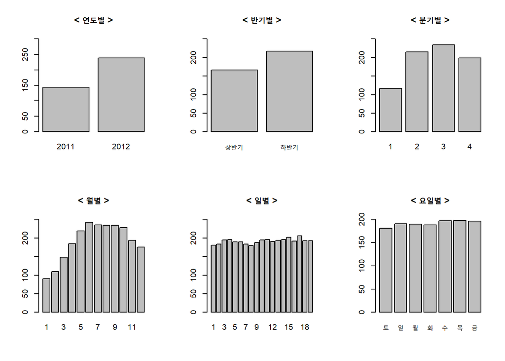

```r
par(mfrow = c(2,3))
barplot(m12_year,names=c(2011,2012), ylim=c(0,300), main='< 연도별 >')
barplot(m12_semester, name=c('상반기','하반기'), ylim=c(0,250), main='< 반기별 >')
barplot(m12_quarter, name=c(1:4), ylim=c(0,250), main='< 분기별 >')

barplot(m12_month, names=c(1:12), ylim=c(0,250), main='< 월별 >')
barplot(m12_day, names=c(1:19), ylim=c(0,250), main='< 일별 >')
barplot(m12_wday, name=c('토','일','월','화','수','목','금'), ylim=c(0,200), main='< 요일별 >')
```

1. 연도별 : 2011년보다 2012년 대여량이 많아짐  
   - 평균기온 찾았을 때, 2011년보다 2012년이 낮아짐
2. 반기별 : 상반기보다 하반기 대여량이 많아짐
3. 분기별 : 3>2>4>1 분기 순으로 많음  
   - 2->3 분기 점차 늘어남 (더운날씨가 점차 풀리면서 대여량이 많아짐)  
   - 4->1 분기 점차 줄어듦 (추운 날씨로 대여량 서서히 줄어듦)  
   => **날씨 및 계절**에 영향을 받아 대여량이 순환되는 구조
4. 월별 : 6월이 가장 많고, 너무 춥지도 덥지도 않은 시기에 대여량이 많음
5. 일별 : 큰 차이가 없음 -> 사용불가
6. 요일별 : 큰 차이가 없음 -> 사용불가
- 적어도 [ 평일 vs. 주말 ] 정도로는 차이가 있을 것이라 생각했는데 아니었음

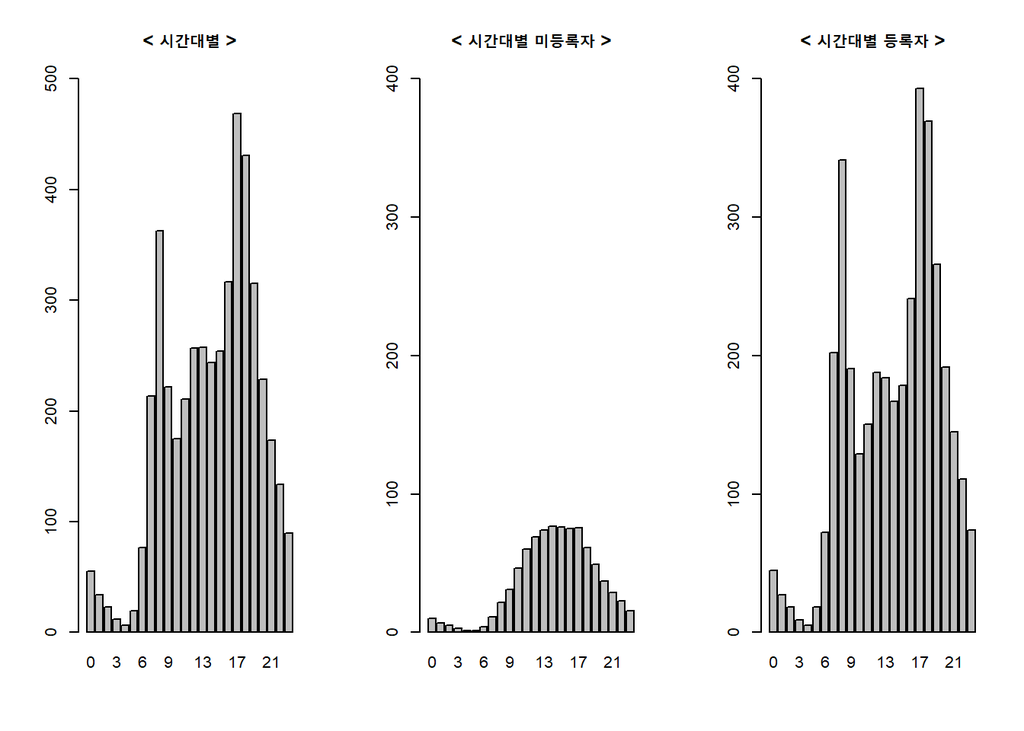

```r
# ii) 등록 여부
par(mfrow = c(1,3))
barplot(m12_hour, names=c(0:23), ylim=c(0,500), main='< 시간대별 >')
barplot(m12_casual, names=c(0:23), ylim=c(0,400), main='< 시간대별 미등록자 >')
barplot(m12_registered, names=c(0:23), ylim=c(0,400), main='< 시간대별 등록자 >')
```

7. 시간대별 : 통근 시간인 8시, 17~18시에 대여량이 가장 많음
8. 시간대별 미등록자 : 일과 시간에 대여량이 조금 있을 뿐, 큰 의미는 없어보임
9. 시간대별 등록자 : 시간대별 그래프와 모양이 거의 같음
- 상당수 등록자를 위주로 대여가 이루어 진다고 볼 수 있음

#### ii) 상관관계 ( 미등록자, 등록자, 대여량 )

```r
###### count 관련
# cor(bikeTr$casual, bikeTr$registered)
# cor(bikeTr$casual, bikeTr$count)
# cor(bikeTr$registered, bikeTr$count)
cor(bikeTr[,10:12])
```

```
##               casual registered     count
## casual     1.0000000  0.4972497 0.6904136
## registered 0.4972497  1.0000000 0.9709481
## count      0.6904136  0.9709481 1.0000000
```

```r
#-> 등록한 사람들은 대여를 많이 한다는 의미
```

#### 2) season

```r
# 참고 : 데이터에 나타난 것이 [ 1-3 / 4-6 / 7-9 / 10-12 ]월로 분류되어 있어서 분기를 나타낸다고 봤음
# 위에서 적은 분기별에 해당하는 내용
```

#### 3) holiday, workingday

```r
# 3) holiday, workingday
# 데이터 상 무엇을 의미하는지 파악이 되질 않아서 일단 범주형으로만 생각하고 넘어감
```